# ASSIGNMENT-4

vivek rao kathheragandla

2024-03-12

```r
library("tidyverse")
library("ISLR")
library("factoextra")
library("flexclust")
```

```r
library("ggplot2")
library("dplyr")
library("caret")
```

#applying the knit functions

```r
data_pharma <- read.csv("C:\\Users\\KATHHERAGANDLA VIVEK\\OneDrive\\Documents\\FML\\Assignment_4\\Pharmaceuticals (1).csv")
head(data_pharma)
```

```
##   Symbol                Name Market_Cap Beta PE_Ratio  ROE  ROA Asset_Turnover
## 1    ABT Abbott Laboratories      68.44 0.32     24.7 26.4 11.8            0.7
## 2    AGN      Allergan, Inc.       7.58 0.41     82.5 12.9  5.5            0.9
## 3    AHM        Amersham plc       6.30 0.46     20.7 14.9  7.8            0.9
## 4    AZN     AstraZeneca PLC      67.63 0.52     21.5 27.4 15.4            0.9
## 5    AVE             Aventis      47.16 0.32     20.1 21.8  7.5            0.6
## 6    BAY            Bayer AG      16.90 1.11     27.9  3.9  1.4            0.6
##   Leverage Rev_Growth Net_Profit_Margin Median_Recommendation Location Exchange
## 1     0.42       7.54              16.1          Moderate Buy       US     NYSE
## 2     0.60       9.16               5.5          Moderate Buy   CANADA     NYSE
## 3     0.27       7.05              11.2            Strong Buy       UK     NYSE
## 4     0.00      15.00              18.0         Moderate Sell       UK     NYSE
## 5     0.34      26.81              12.9          Moderate Buy   FRANCE     NYSE
## 6     0.00      -3.17               2.6                  Hold  GERMANY     NYSE
```

```r
summary(data_pharma)
```

```
##     Symbol              Name             Market_Cap          Beta
##  Length:21          Length:21          Min.   :  0.41   Min.   :0.1800
##  Class :character   Class :character   1st Qu.:  6.30   1st Qu.:0.3500
##  Mode  :character   Mode  :character   Median : 48.19   Median :0.4600
##                                        Mean   : 57.65   Mean   :0.5257
##                                        3rd Qu.: 73.84   3rd Qu.:0.6500
##                                        Max.   :199.47   Max.   :1.1100
##     PE_Ratio          ROE            ROA        Asset_Turnover    Leverage
##  Min.   : 3.60   Min.   : 3.9   Min.   : 1.40   Min.   :0.3    Min.   :0.0000
##  1st Qu.:18.90   1st Qu.:14.9   1st Qu.: 5.70   1st Qu.:0.6    1st Qu.:0.1600
##  Median :21.50   Median :22.6   Median :11.20   Median :0.6    Median :0.3400
##  Mean   :25.46   Mean   :25.8   Mean   :10.51   Mean   :0.7    Mean   :0.5857
##  3rd Qu.:27.90   3rd Qu.:31.0   3rd Qu.:15.00   3rd Qu.:0.9    3rd Qu.:0.6000
##  Max.   :82.50   Max.   :62.9   Max.   :20.30   Max.   :1.1    Max.   :3.5100
##    Rev_Growth    Net_Profit_Margin Median_Recommendation   Location
##  Min.   :-3.17   Min.   : 2.6      Length:21             Length:21
##  1st Qu.: 6.38   1st Qu.:11.2      Class :character      Class :character
##  Median : 9.37   Median :16.1      Mode  :character      Mode  :character
##  Mean   :13.37   Mean   :15.7
##  3rd Qu.:21.87   3rd Qu.:21.1
##  Max.   :34.21   Max.   :25.5
##    Exchange
##  Length:21
##  Class :character
##  Mode  :character
##
##
##
```

##QUESTION-A - Use only the numerical variables (1 to 9) to cluster the 21 firms. Justify the various choices made in conducting the cluster analysis, such as weights for different variables, the specific clustering algorithm(s) used, the number of clusters formed, and so on.

```r
#Performing z-score scaling for the pahrmaceuticals dataframe
Scaling_pharma_data <- scale(data_pharma[,3:11])
summary(Scaling_pharma_data)
```

```
##    Market_Cap           Beta            PE_Ratio            ROE
##  Min.   :-0.9768   Min.   :-1.3466   Min.   :-1.3404   Min.   :-1.4515
##  1st Qu.:-0.8763   1st Qu.:-0.6844   1st Qu.:-0.4023   1st Qu.:-0.7223
##  Median :-0.1614   Median :-0.2560   Median :-0.2429   Median :-0.2118
##  Mean   : 0.0000   Mean   : 0.0000   Mean   : 0.0000   Mean   : 0.0000
##  3rd Qu.: 0.2762   3rd Qu.: 0.4841   3rd Qu.: 0.1495   3rd Qu.: 0.3450
##  Max.   : 2.4200   Max.   : 2.2758   Max.   : 3.4971   Max.   : 2.4597
##       ROA          Asset_Turnover       Leverage          Rev_Growth
##  Min.   :-1.7128   Min.   :-1.8451   Min.   :-0.74966   Min.   :-1.4971
##  1st Qu.:-0.9047   1st Qu.:-0.4613   1st Qu.:-0.54487   1st Qu.:-0.6328
##  Median : 0.1289   Median :-0.4613   Median :-0.31449   Median :-0.3621
##  Mean   : 0.0000   Mean   : 0.0000   Mean   : 0.00000   Mean   : 0.0000
##  3rd Qu.: 0.8430   3rd Qu.: 0.9225   3rd Qu.: 0.01828   3rd Qu.: 0.7693
##  Max.   : 1.8389   Max.   : 1.8451   Max.   : 3.74280   Max.   : 1.8862
##  Net_Profit_Margin
##  Min.   :-1.99560
##  1st Qu.:-0.68504
##  Median : 0.06168
##  Mean   : 0.00000
##  3rd Qu.: 0.82364
##  Max.   : 1.49416
```

```r
#Performing range scaling for the the dataframe
range_pharma <- scale(data_pharma[,3:11])
#summarizing the scaled data frame
summary(range_pharma)
```

```
##    Market_Cap           Beta            PE_Ratio            ROE
##  Min.   :-0.9768   Min.   :-1.3466   Min.   :-1.3404   Min.   :-1.4515
##  1st Qu.:-0.8763   1st Qu.:-0.6844   1st Qu.:-0.4023   1st Qu.:-0.7223
##  Median :-0.1614   Median :-0.2560   Median :-0.2429   Median :-0.2118
##  Mean   : 0.0000   Mean   : 0.0000   Mean   : 0.0000   Mean   : 0.0000
##  3rd Qu.: 0.2762   3rd Qu.: 0.4841   3rd Qu.: 0.1495   3rd Qu.: 0.3450
##  Max.   : 2.4200   Max.   : 2.2758   Max.   : 3.4971   Max.   : 2.4597
##       ROA          Asset_Turnover       Leverage          Rev_Growth
##  Min.   :-1.7128   Min.   :-1.8451   Min.   :-0.74966   Min.   :-1.4971
##  1st Qu.:-0.9047   1st Qu.:-0.4613   1st Qu.:-0.54487   1st Qu.:-0.6328
##  Median : 0.1289   Median :-0.4613   Median :-0.31449   Median :-0.3621
##  Mean   : 0.0000   Mean   : 0.0000   Mean   : 0.00000   Mean   : 0.0000
##  3rd Qu.: 0.8430   3rd Qu.: 0.9225   3rd Qu.: 0.01828   3rd Qu.: 0.7693
##  Max.   : 1.8389   Max.   : 1.8451   Max.   : 3.74280   Max.   : 1.8862
##  Net_Profit_Margin
##  Min.   :-1.99560
##  1st Qu.:-0.68504
##  Median : 0.06168
##  Mean   : 0.00000
##  3rd Qu.: 0.82364
##  Max.   : 1.49416
```

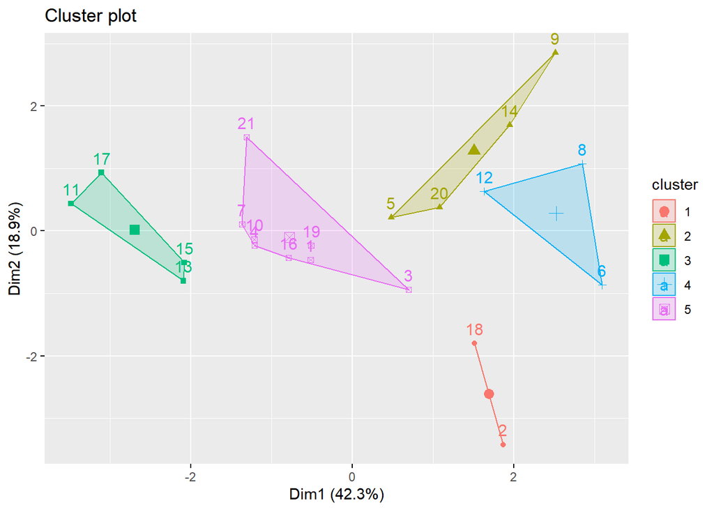

```r
#applying K-means clustering for the scaled data
kmeans_1 <- kmeans(Scaling_pharma_data, centers = 5, nstart = 25)
#visualizing the clusters on agraph
fviz_cluster(kmeans_1, data = Scaling_pharma_data)
```

```r
#Assuming kmeans_1 contains the results of your k-means clustering
print(kmeans_1)
```

```
## K-means clustering with 5 clusters of sizes 2, 4, 4, 3, 8
##
## Cluster means:
##    Market_Cap       Beta    PE_Ratio        ROE        ROA Asset_Turnover
## 1 -0.43925134 -0.4701800  2.70002464 -0.8349525 -0.9234951      0.2306328
## 2 -0.76022489  0.2796041 -0.47742380 -0.7438022 -0.8107428     -1.2684804
## 3  1.69558112 -0.1780563 -0.19845823  1.2349879  1.3503431      1.1531640
## 4 -0.87051511  1.3409869 -0.05284434 -0.6184015 -1.1928478     -0.4612656
## 5 -0.03142211 -0.4360989 -0.31724852  0.1950459  0.4083915      0.1729746
##      Leverage Rev_Growth Net_Profit_Margin
## 1 -0.14170336 -0.1168459      -1.416514761
## 2  0.06308085  1.5180158      -0.006893899
## 3 -0.46807818  0.4671788       0.591242521
## 4  1.36644699 -0.6912914      -1.320000179
## 5 -0.27449312 -0.7041516       0.556954446
##
## Clustering vector:
##  [1] 5 1 5 5 2 4 5 4 2 5 3 4 3 2 3 5 3 1 5 2 5
##
## Within cluster sum of squares by cluster:
## [1]  2.803505 12.791257  9.284424 15.595925 21.879320
##  (between_SS / total_SS =  65.4 %)
##
## Available components:
##
## [1] "cluster"      "centers"      "totss"        "withinss"     "tot.withinss"
## [6] "betweenss"    "size"         "iter"         "ifault"
```

##OVERVIEW of the K-means Clustering:- ##The summary function performed on the k-means data gives the infromation on 9 variables for the 21 pharmaceutical companies. There are a total of 5 clusters with 5 centeroid points and the sizes of the clusters are (2, 3, 4, 4, 8).

##QUESTION-B - Interpret the clusters with respect to the numerical variables used in forming the clusters.

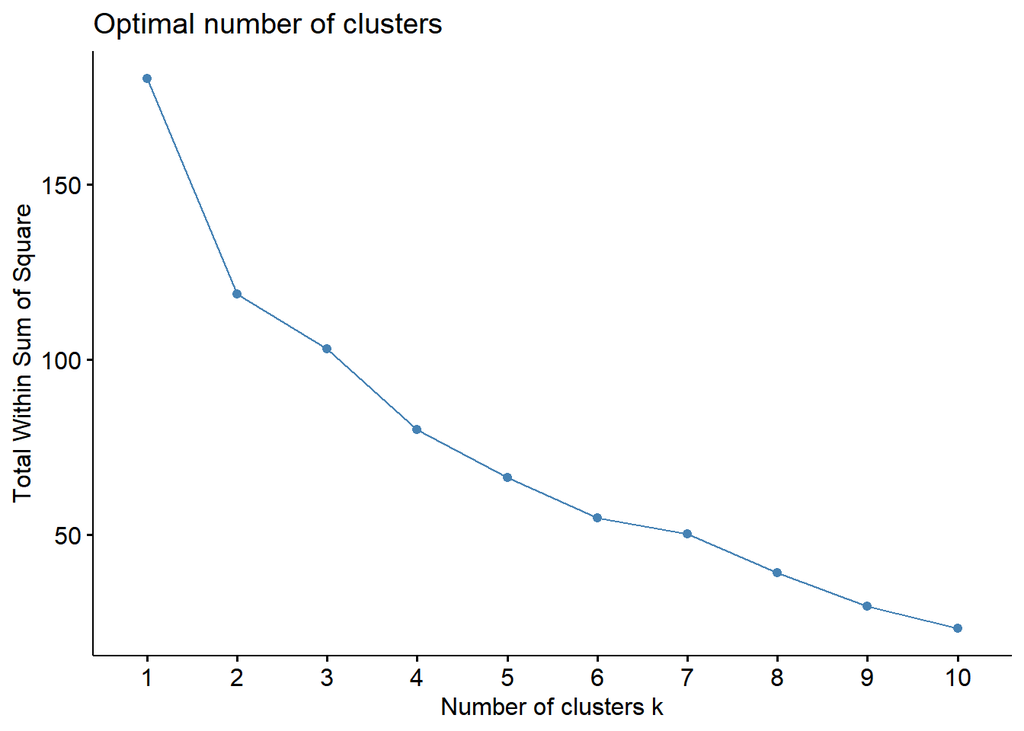

```r
#plotting the number of clusters vs the total value
fviz_nbclust(Scaling_pharma_data, kmeans, method = "wss")
```

** Here in this plot we can clearly see that the graph is not forming an elbow shape and it is getting flattened slightly at k=4 and k=6

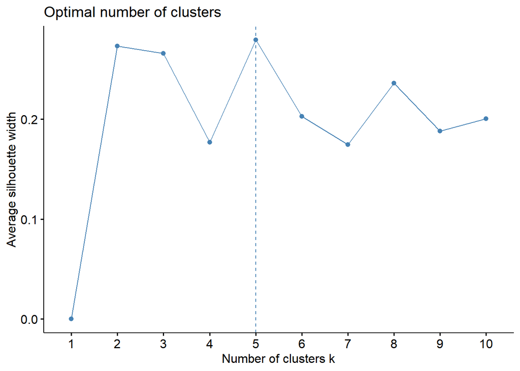

```r
#figuring ou the number of optimal clusters by plotting the number of clusters
#against average silhoutte width
fviz_nbclust(Scaling_pharma_data, kmeans, method = "silhouette")
```

##By judging from the silhoutte graph we easily conclude that 5 clusters is the best and optimal solution for this k-means clustering.

##QUESTION-C - Is there a pattern in the clusters with respect to the numerical variables (10 to 12)? (those not used in forming the clusters)

```r
#Calculating the mean value from the actual data that is plotted in the clusters
#perfroming the aggregate function for the pharma data
aggregate(data_pharma[3:11], by=list(cluster=kmeans_1$cluster), mean)
```

```
##   cluster Market_Cap    Beta PE_Ratio      ROE       ROA Asset_Turnover
## 1       1  31.910000 0.40500  69.5000 13.20000  5.600000         0.7500
## 2       2  13.100000 0.59750  17.6750 14.57500  6.200000         0.4250
## 3       3 157.017500 0.48000  22.2250 44.42500 17.700000         0.9500
## 4       4   6.636667 0.87000  24.6000 16.46667  4.166667         0.6000
## 5       5  55.810000 0.41375  20.2875 28.73750 12.687500         0.7375
##   Leverage Rev_Growth Net_Profit_Margin
## 1 0.475000  12.080000          6.400000
## 2 0.635000  30.142500         15.650000
## 3 0.220000  18.532500         19.575000
## 4 1.653333   5.733333          7.033333
## 5 0.371250   5.591250         19.350000
```

```r
#perfroming the merging of the data frames using cbind
temp_data <- cbind(data_pharma, cluster = kmeans_1$cluster)
tibble(temp_data)
```

```
## # A tibble: 21 × 15
##    Symbol Name     Market_Cap  Beta PE_Ratio   ROE   ROA Asset_Turnover Leverage
##    <chr>  <chr>         <dbl> <dbl>    <dbl> <dbl> <dbl>          <dbl>    <dbl>
##  1 ABT    Abbott …      68.4   0.32     24.7  26.4  11.8            0.7     0.42
##  2 AGN    Allerga…       7.58  0.41     82.5  12.9   5.5            0.9     0.6
##  3 AHM    Amersha…       6.3   0.46     20.7  14.9   7.8            0.9     0.27
##  4 AZN    AstraZe…      67.6   0.52     21.5  27.4  15.4            0.9     0
##  5 AVE    Aventis       47.2   0.32     20.1  21.8   7.5            0.6     0.34
##  6 BAY    Bayer AG      16.9   1.11     27.9   3.9   1.4            0.6     0
##  7 BMY    Bristol…      51.3   0.5      13.9  34.8  15.1            0.9     0.57
##  8 CHTT   Chattem…       0.41  0.85     26    24.1   4.3            0.6     3.51
##  9 ELN    Elan Co…       0.78  1.08      3.6  15.1   5.1            0.3     1.07
## 10 LLY    Eli Lil…      73.8   0.18     27.9  31    13.5            0.6     0.53
## # ℹ 11 more rows
## # ℹ 6 more variables: Rev_Growth <dbl>, Net_Profit_Margin <dbl>,
## #   Median_Recommendation <chr>, Location <chr>, Exchange <chr>, cluster <int>
```